# How has release-decade representation changed in Rolling Stone’s album lists?

Author

Brandon Linck-Hernandez

Published

November 1, 2026

## 1. Introduction

Rolling Stone Magazine’s *500 Greatest Albums of All Time* has been published in three editions. Each ranking is a judgement on an album’s (studio or complication) industrial significance and popularity rather than an objective assessment of album revenue. We use the CRISP-DM framework and Tidyverse tools in R Studio to assess the changing composition of this list between 2003-2020.

The study aims to describe and show trends within the data set to understand how genre popularity has changed over time.

## 2.1 Business Understanding

Listed rankings of music will always be subjective. The patterns in genres that are favorable and eras that are continually popular should lend towards those within the marketing realm or, to aid artists to change their brand in the support of their individual success; to see what’s trending may indicate what to tap into. Equally, artists can be advised on whether to engage more with a certain genre if it appears it is following a trend.

### 2.2 Objective

Questions to answer:

1. How has the representation of albums within the top 500 changed across the years
2. Which genres appear in all three ranks. How reliable is a genre at being consistently well ranked?

## 3.0 Data Understanding & Initial Exploration

We imported raw data from the rolling stone ranked albums list to use dplyr to clean. The raw data has one row per album, with artist name, title, year of release, genre, album type and yearly rank. The data of interest is continuous and ordered on a timeline from years 2003-2020.

**Note**

To begin: Row and column counts were checked with nrow(), ncol(), glimpse().

We want to understand what each data type is before changing any behaviors; release year appears as -> does not need converting as years are whole numbers.

### 3.1 Missing Values

Each ranking column contains 191 missing values, leaving 500 recorded entries per edition. Missing ranks are retained to avoid selection bias; an album may have a recorded position in one edition but not another.

Release year is complete, allowing all albums to be grouped to a decade. Genre is missing for 164 albums; these records are retained and labelled “Genre not recorded” for visualisation

### 3.2 Accounting for duplicates and shared values.

We want to remove any duplicates of albums i.e studio and complication which will affect ranking, yet still including albums by same artist or Na’s. Furthermore, ranks may be shared and we want to reassign or disclude these rankings.

### 3.3 Selecting Relevant Variables

Here we assign our identifiers and cut down the data, focusing on Rolling Stone ranking and year of release.

### 3.4 Ranking Values

Across the 2003 to 2020 editions, four rows share a rank (in 2003 only): in each case the albums and artists are different, so they are not duplicates. These ranks have been left unchanged because no adequate replacements could be found.

### Repeated Rankings

Four albums have repeated shared rankings within the data. Since they are different artists and different names, they are not regarded as duplicates hence are retained.

### 3.6 Release Decade Column

Albums were grouped into release decades using integer division. Mutate() adds this grouping while retaining every album record

**Note**

The calculation (release_year / 10) * 10 groups allows for a comparison of both individual years and decades without loop.

### 3.7 Counting albums per decade

Grouping by release decade; counting ranks per edition (year) and summarising in one row:

### 3.8 Ordering our release table

Here, we resort our row ordering; nothing in the data but decade order changes

### 3.8 Calculating and displaying changes

We calculate the change in album counts for each release decade between 2003 and 2020, then sort the results from the largest increase to the largest decrease. Positive values indicate more entries in 202 & negative values indicate fewer.

### 3.9 Formatting Data for Modelling Phase

We prepare longer columns for our modelling and label unrecorded values.This leaves exactly the 500 albums in each of the 2003, 2012 and 2020 lists; all prepared for ggplot2 use and doesn’t need converting since same weight.

### 3.10 Genre Counts

Genres are counted by genre and edition from cleaned data in preparation for modelling. Absent values labelled as zeros; not missing genre information.

### 3.11 Changes in representation

Genre counts were arranged into separate columns for each edition. The differences were calculated and sorted from the largest increase to the largest decrease.

## 4.0 Modelling and Analysis

We compare album counts by release decade and genre across the 2003, 2012 and 2020 editions. A histogram suits the outcomes we wish to meet because release year is continuous and each edition has 500 albums. Ten-year bins give one bar per decade, and faceting lets us compare editions directly, seeing an overall shape of distribution.

No predictive model is fitted: the questions are descriptive; analysis consists of quantifying differences between the lists.

### 4.1 Genre Density per Release Year

Figure 1. Histogram formatted with release years in decade intervals; displays the distribution of genres along a timeline from 1950-2020 as ranked by each edition of Rolling Stone magazine.

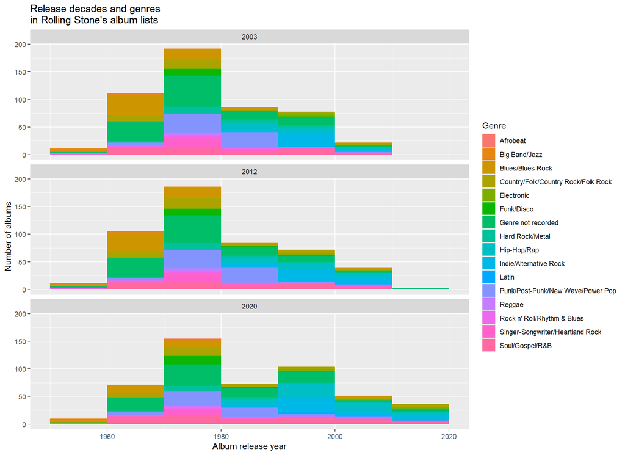

Genres and music from the 1970s remained the most represented release decade across all three editions. The 1960s experienced the largest decrease, falling from 111 to 71 entries. In contrast, representation of the 1990s increased from 78 to 104 albums. Albums from the 2000s rose from 22 to 51 and the 2010s reached 36 entries in 2020.

### 4.2 Changes in yearly representation of genres

Figure 2. Changes in genre representation between the 2003 and 2020. Bars represent the difference in album counts, being color coded to show positive or negative changes. Rather than a change in ranking position, it measures the increase or decline in genre density. “Genre not recorded” identifies albums with missing genre information

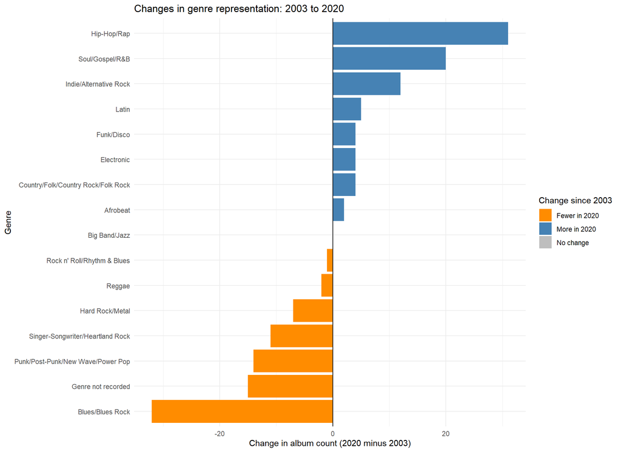

Most apparent is the large increase in Hip-Hop/Rap albums; rising from 26 albums in 2003 to 57 in 2020. Blues/Blues Rock experienced the largest decline, falling from 61 to 29 albums. Big Band/Jazz remained unchanged

## 5.0 Evaluation

As shown by Figure 2, the analysis shows a change in the counts of albums; Hip-Hop/Rap albums showed the largest increase, gaining 31 entries, followed by Soul/Gospel/R&B with 20 and Indie/Alternative Rock with 12. Blues/Blues Rock experienced the largest decline, losing 32 entries.

From a business perspective, the results may enable the targeting of genres within the pool to boost artist success (although this requires data on revenue per genre and commercial success). Especially in the current era of the 2020s, Reggae ton artists like Bad Bunny have seen record breaking growth and boost in popularity; in relation to our data it may be a result of engagement with two key genres emerging within the current decade - Latin and Rap.

### 5.1 Key Limitations

### Missing Data

**Note**

A key hindrance to the project was the nature of the data- missing genre information limits the conclusions: As well as early works from 1950s onward coming with the challenge of loss of record, many entries in 2003 and 22% in 2020 also had no recorded genre since Rolling Stone Magazine created the data set from Spotify imports.

Artists during this time have moved their rights from one producer to another (Taylor Swift, Prince, Thom Yorke) or in the world of activism, boycotts to Spotify (MBV, Massive Attack) have affected availability to audiences and to those selecting ranks for albums. Although absences have been accounted for, there is a discrepancy within the data in regards to rank and the overall number of albums within plots, hence some genre values may be skewed incorrectly.

### Lack of Neutral Measure

**Note**

The rankings reflect the judgement of each edition’s voting panel; findings describe Rolling Stone’s canon but not a general population. [From Rolling Stone Magazine website] panel sizes are reported, but its age and background are not, so the 1970s representation may partly be influenced by recall bias, though this cannot be tested currently.The decision to keep Spotify measures excluded because of missing and unreliable values meant also that younger audiences’ listening behaviour is not represented. Therefore conclusions should not be seen to fully reflect current consumer demand.”

### No real Utility for prediction

**Note**

Although stated in the modelling section (4.0) this study uses no model for looking prospectively towards ‘future trends’ or growth in kinds of music. Despite the sample size being too small to fit even a simple linear regression model, essentially we have looked at a snapshot of the past to say what worked previously hence it would be unfair to promise a reliable forecast of what’s to come.

### Note of Honesty with Accessibility

**Note**

Admittedly, Figure 1 although displaying results which do aim to answer the research question- the colors selected are not particularly accessible. For reproducible data, and despite the time restraint on the project, an immediate improvement that should be prioritized is to choose colors which still represent the analysis well, but are easier for readability.

## 6.0 Deployment and Future Improvements

The analysis is delivered as a Quarto HTML report containing two figures and their interpretation. The accompanying R Project includes the source CSV, analysis code and README instructions so the findings can be reproduced.

### 6.1 Improving Data Completeness

The first priority is to investigate the 164 albums without recorded genres. Verified classifications could be collected from a documented external source, using consistent rules for broad and overlapping genres. These records should be matched by artist and album, with source references retained. Comparing the original and enriched results would show whether missing classifications substantially affect the observed changes.

### 6.2 Strengthening Validation

Repeated 2003 ranking positions should be checked against the original published list. Any verified corrections should be documented. Automated checks could then confirm that each edition contains 500 entries, valid ranking positions and no unintended duplicate album records.

### 6.3 Extending the Comparisons

Future analysis could distinguish albums entering, leaving and remaining in each edition. This would reveal whether stable genre totals conceal substantial changes in the albums selected. Restricting a comparison to albums released before 2003 would also help separate changes in selection from the availability of newer releases.

### 6.4 Assessing Business Relevance

Commercial recommendations would require a separate analysis using recent streaming, sales or audience data from appropriate sources. By using streaming data from Bandcamp and Spotify, it may address the challenges brought by artist withdrawal leading to absent values. Furthermore, this could test whether increased representation in the lists is associated with consumer demand. MusicBrainz could support album identification by using its SQL query function.

### 7.0 Acknowledgements

Bandcamp (n.d.) About us. Available at: https://bandcamp.com/about (Accessed: 7 November 2026).

Chapman, P. et al. (2000) CRISP-DM 1.0: Step-by-step data mining guide. SPSS Inc.

Rolling Stone (2020) The 500 greatest albums of all time. Available at: https://www.rollingstone.com/music/music-lists/best-albums-of-all-time-1062063/ (Accessed: 7 November 2026).

Wickham, H. et al. (2019) ‘Welcome to the tidyverse’, Journal of Open Source Software, 4(43), article 1686. https://doi.org/10.21105/joss.01686.